# Lab 1: Data Science in R

Christof Seiler

6/24/2019

# Background

This lab is written in R markdown. This format promotes reproducibility and facilitates collaborative sharing of statistical analyses. You can run it either on RStudio cloud or locally on your laptop by installing RStudio (download [here](https://www.rstudio.com/)).

During this lab, we will get familiar with the following concepts:

# R and R markdown

Before we start using R, we need to install all the necessary packages. We need to first install them if there are not already in our system, then, we need to load them into our current session.

Here is a code chunk that you can reuse for your own analyses. Just make sure to replace the package names on the first line. The rest of the code stays the same no matter your analysis.

```r
pkgs_needed = c("tidyverse", "magrittr", "glmnet", "bootstrap",
                "lars", "broom", "cowplot", "ggthemes")
letsinstall = setdiff(pkgs_needed, installed.packages())
if (length(letsinstall) > 0) {
  install.packages(letsinstall)
}
```

Once they are install, you can load them into your current R session. This will make it possible to use functions from these packages.

```r
library("tidyverse")
library("magrittr")
library("glmnet")
library("bootstrap")
library("lars")
library("broom")
library("cowplot")
library("ggthemes")
theme_set(theme_few())
```

To compile this notebook into a html report use `Knit` icon above the RStudio code editor. At this point the compilation will fail. To make it work you have to fix the TODO that are spread out in the document. Additionally, there are a total of 12 questions and one bonus question.

# Plotting

Try to calculate the number $\pi$ yourself using computer simulations. It is usually very helpful to keep plotting every step of your simulation to make sure that your code is correct. I recommend using the R package `ggplot2` for plotting. It implements the grammar of graphics that allows you build plots in a modular way. Here is an example to plot points. We use the data set `mpg` from package `ggplot2`.

```r
mpg
```

```
## # A tibble: 234 x 11
##    manufacturer model displ  year   cyl trans drv     cty   hwy fl    class
##    <chr>        <chr> <dbl> <int> <int> <chr> <chr> <int> <int> <chr> <chr>
##  1 audi         a4      1.8  1999     4 auto… f        18    29 p     comp…
##  2 audi         a4      1.8  1999     4 manu… f        21    29 p     comp…
##  3 audi         a4      2    2008     4 manu… f        20    31 p     comp…
##  4 audi         a4      2    2008     4 auto… f        21    30 p     comp…
##  5 audi         a4      2.8  1999     6 auto… f        16    26 p     comp…
##  6 audi         a4      2.8  1999     6 manu… f        18    26 p     comp…
##  7 audi         a4      3.1  2008     6 auto… f        18    27 p     comp…
##  8 audi         a4 q…   1.8  1999     4 manu… 4        18    26 p     comp…
##  9 audi         a4 q…   1.8  1999     4 auto… 4        16    25 p     comp…
## 10 audi         a4 q…   2    2008     4 manu… 4        20    28 p     comp…
## # … with 224 more rows
```

Now plot highway miles per gallon `hwy` as a function of engine displacement, in liters `displ`. To query the dataset you can use `?mpg` in R.

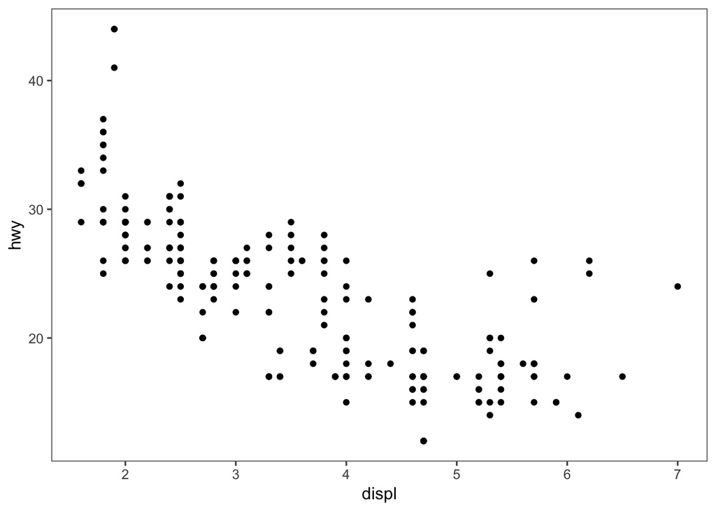

```r
ggplot(data = mpg) +
  geom_point(mapping = aes(x = displ, y = hwy))
```

For more background use the online book: [R for Data Science](https://r4ds.had.co.nz/data-visualisation.html). Plotting is very important in data science. It helps you debug your code and your data. Sometimes you may also discover something unexpected! Such as batch effects, which might be hard to detect in other ways.

**Question 1**: Try to add a smooth function through the data points in the previous plot. Hint: You don’t have to compute the smoothing curve yourself. There is a `geom_*` function for that. Try to find it in the book chapter [R for Data Science](https://r4ds.had.co.nz/data-visualisation.html).

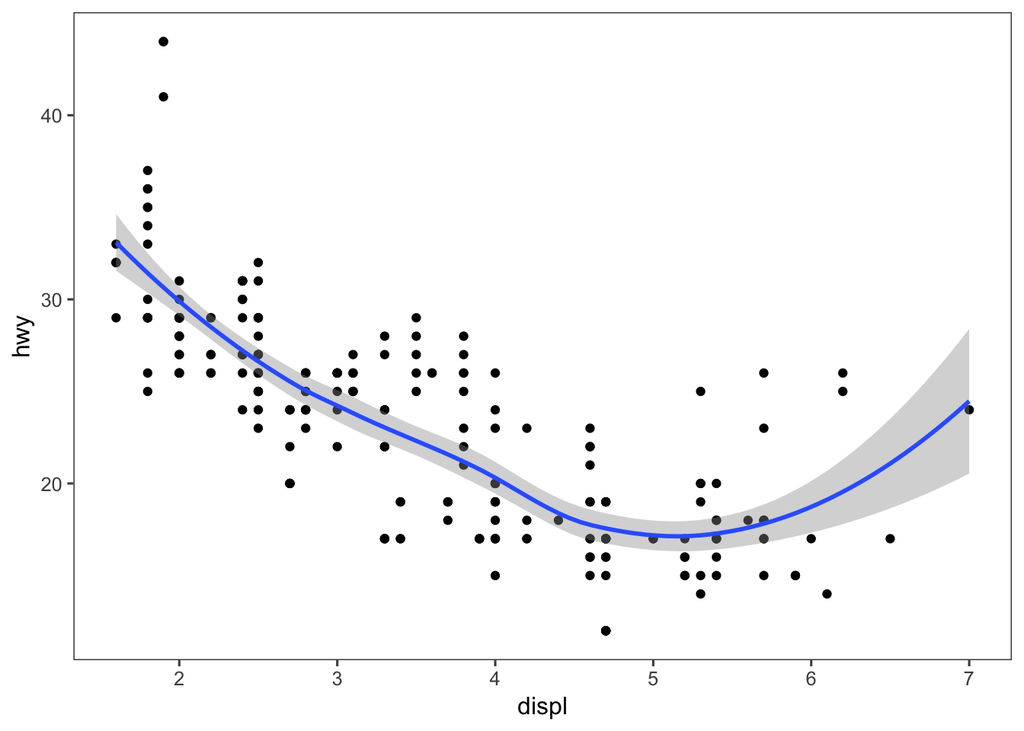

```r
ggplot(data = mpg, aes(x = displ, y = hwy)) +
  geom_point() +
  geom_smooth()
```

# Computer Simulations

```r
set.seed(25)
n = 1000
sample_pi_table = function() {
  tibble(
    x = runif(n),
    y = runif(n)
  )
}
tb_pi = sample_pi_table()
tb_pi
```

```
## # A tibble: 1,000 x 2
##         x      y
##     <dbl>  <dbl>
##  1 0.416  0.896
##  2 0.695  0.167
##  3 0.149  0.940
##  4 0.897  0.0373
##  5 0.124  0.227
##  6 0.985  0.797
##  7 0.626  0.595
##  8 0.338  0.318
##  9 0.0668 0.320
## 10 0.282  0.860
## # … with 990 more rows
```

**Question 2**: Why do we need to call `set.seed`? Hint:

1. Comment out the `set.seed` function like this `#set.seed(25)`
2. Execute the code chunk twice and compare the results
3. Then uncomment `set.seed` again
4. Execute the code chunk twice and compare the results
5. What changes?

Answer: `set.seed` defines the starting point of generating random numbers. By setting the seed you will be able to get the same sequence of random number every time. This is useful for reproducibility.

You can also learn what `set.seed` does by reading the R documentation like this `?set.seed` (type in console).

**Question 3**: How accurate is your approximation? Hint:

Here is a template that you can as a starting point:

```r
sample_pi = function() {
  sample_pi_table() %>%
    mutate(inside = ifelse(sqrt(x^2 + y^2) < 1, "yes", "no")) %>%
    summarize(mean(inside == "yes") * 4) %>%
    as.numeric()
}
sim_res = replicate(1000, sample_pi())
mean(sim_res)
```

```
## [1] 3.139256
```

```r
sd(sim_res)
```

```
## [1] 0.05208131
```

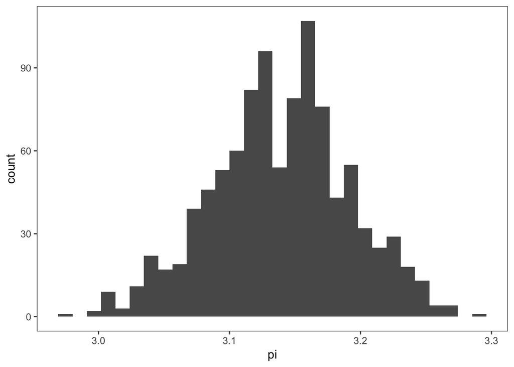

```r
ggplot(tibble(pi = sim_res), aes(x = pi)) +
  geom_histogram()
```

Note that I used the pipe operator here `%>%`. This is very common in R programming. It’s often a more convenient way of writing encapsulated functions. For instance, you can rewrite this sequence of commands:

- `fun_f(fun_g(fun_h(data_x)))`

using the pipe operator:

- `data_x %>% fun_h %>% fun_g %>% fun_f`

# Bootstrap Confidence Intervals

During the lecture, we looked at the bootstrap distribution of height of the 18 year old Dutch men. We compared the observed average height to the bootstrap distribution. Sometimes it is helpful to further summarize the bootstrap distribution. One way is to compute confidence intervals. A 95% confidence interval tells you that if you repeated the survey many times, then the mean height would be within the interval 95% of the time.

**Question 4**: First draw a random sample of size $n = 1000$ from a normal distribution with mean $\mu = 182$ and standard deviation $\sigma = 7$. In R, this can be done with `rnorm`.

```r
set.seed(41)
n = 1000
mu = 182
sigma = 7
tb_survey = tibble(
  height = rnorm(n = n, mean = mu, sd = sigma)
  )
```

**Question 5**: Now plot a histogram of the survey data using `ggplot2`.

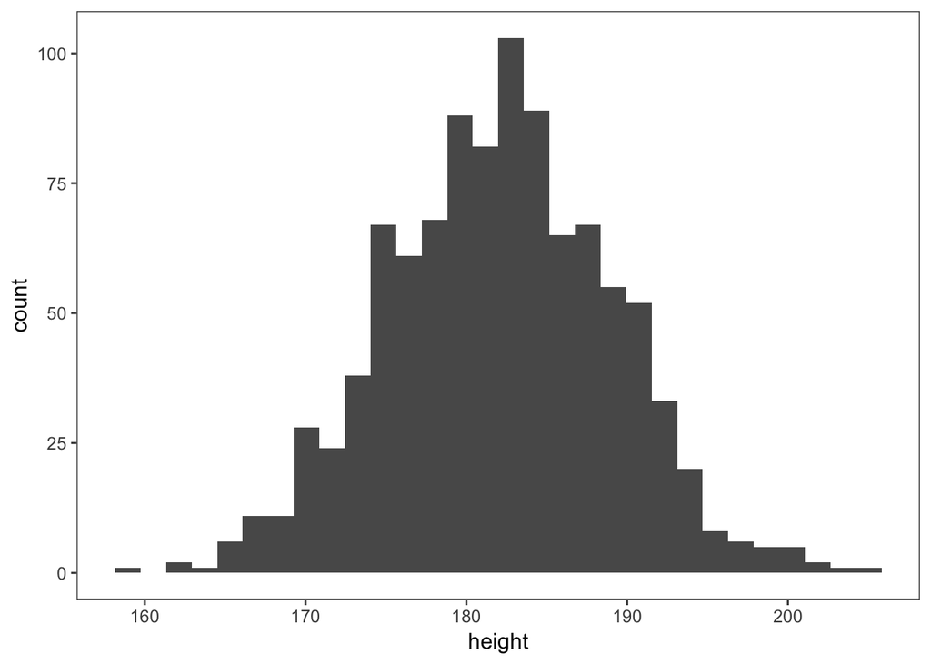

```r
ggplot(tb_survey, aes(height)) +
  geom_histogram()
```

Now, let’s repeat the survey many times and compute the mean height every time to obtain the bootstrap distribution. The key functions that you will need for this is `replicate` and `sample`.

Consider the function `sample` first:

```r
sample(x, size, replace = FALSE)
```

- The first argument `x` is a vector of items that we want to sample from.
- The second argument `size` is the sample size.
- The third argument `replace` is a bit trickier. Let’s look at some simulations to understand it better:

```r
set.seed(34)
try1 = sample(1:10, size = 10, replace = FALSE)
try1
```

```
##  [1]  5  9  8  2  7 10  6  3  1  4
```

```r
table(try1)
```

```
## try1
##  1  2  3  4  5  6  7  8  9 10
##  1  1  1  1  1  1  1  1  1  1
```

```r
try2 = sample(1:10, size = 10, replace = TRUE)
try2
```

```
##  [1] 4 5 8 1 2 9 9 1 5 5
```

```r
table(try2)
```

```
## try2
## 1 2 4 5 8 9
## 2 1 1 3 1 2
```

**Question 6**: What is the difference?

Answer: `replace = FALSE` picks every element at most ones. `replace = TRUE` can pick some elements multiple times.

**Question 7**: Now that we understand `sample` a bit better, we can continue and use it many times using `replicate`. Hint: To obtain a valid bootstrap sample, you will need to sample with replacement.

```r
draw_bootstrap_sample = function() {
  n = length(tb_survey$height)
  bootstrap_sample = sample(x = tb_survey$height, size = n, replace = TRUE)
  mean(bootstrap_sample)
}
B = 5000
mean_star = replicate(B, draw_bootstrap_sample())
tb_height = tibble(height = mean_star)
```

**Question 8**: Calculate the 95% confidence interval using function `quantile`.

```r
low = quantile(mean_star, probs = 0.025)
high = quantile(mean_star, probs = 0.975)
```

**Question 9**: Add them to your plot using `geom_vline`.

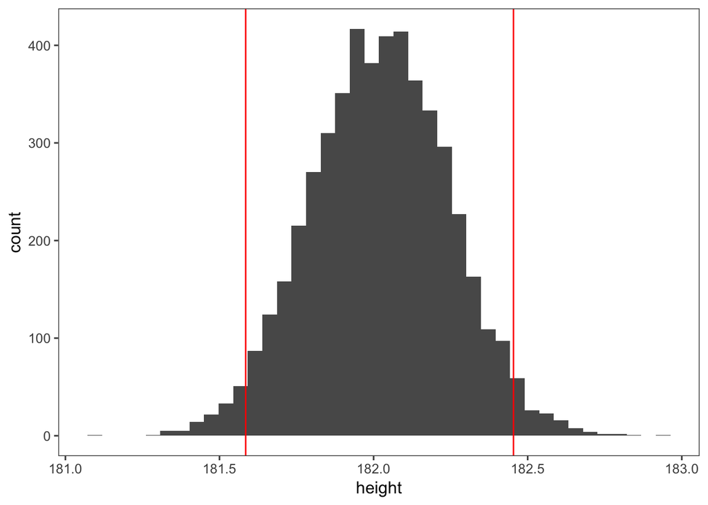

```r
ggplot(tb_height, aes(height)) +
  geom_histogram(bins = 40) +
  geom_vline(xintercept = low, color = "red") +
  geom_vline(xintercept = high, color = "red")
```

**Question 10**: There is a nicer way to color the histogram by adding an addition column (using `mutate`) to the height table indicating whether the value is within the 95% confidence intervals. Then you can use this additional column to color the histogram using the `fill` argument in the aesthetics `aes`.

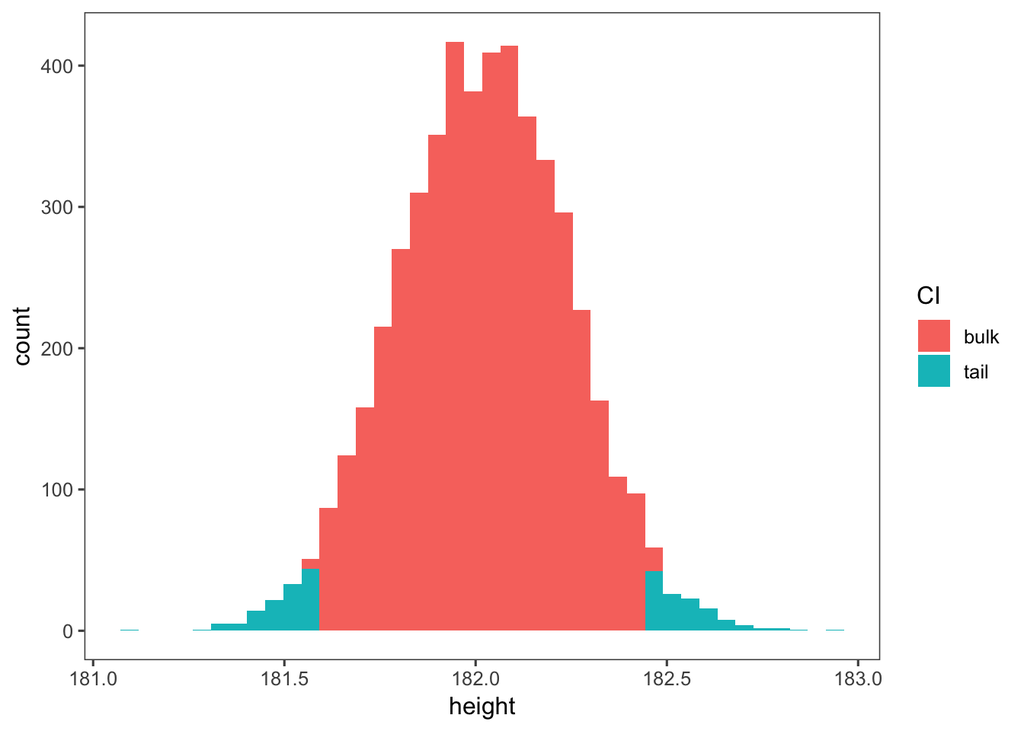

```r
tb_height %<>% mutate(
  CI = ifelse(height > high | height < low, "tail", "bulk")
  )
ggplot(tb_height, aes(height, fill = CI)) +
  geom_histogram(bins = 40)
```

**Bonus Question**: Try to calculate and plot confidence intervals for the Law School example from the lecture.

```r
data(law)
theta_hat = cor(law$LSAT, law$GPA)
theta_hat
```

```
## [1] 0.7763745
```

```r
draw_bootstrap_sample = function() {
  n = dim(law)[1]
  ind = sample(n, replace = TRUE)
  return(cor(law[ind,]$LSAT, law[ind,]$GPA))
}
B = 40000
theta_star = replicate(B, draw_bootstrap_sample())
quantile(theta_star, probs = c(0.025, 0.975))
```

```
##      2.5%     97.5%
## 0.4610565 0.9623387
```

# Fitting Models

We will now try fit a ridge and sparse regression model to the `diabetes` dataset from the lecture.

```r
data("diabetes")
X = diabetes$x
y = diabetes$y
```

First, we try to fit the ridge regression model using the function `glmnet` from package `glmnet`.

```r
ridge_fit = glmnet(x = X, y = y, alpha = 0)
```

The argument `alpha = 0` indicates that we are using the ridge regression model. To use the Lasso model, we can change it to `alpha = 1` instead. It is also possible to fit a model that is a compromise between both by choosing a number between 0 and 1.

Now let’s try to find the optimal regularization parameter `lambda` by cross-validation. Luckily, cross-validation is already build into the `glmnet` package. The syntax is as follows:

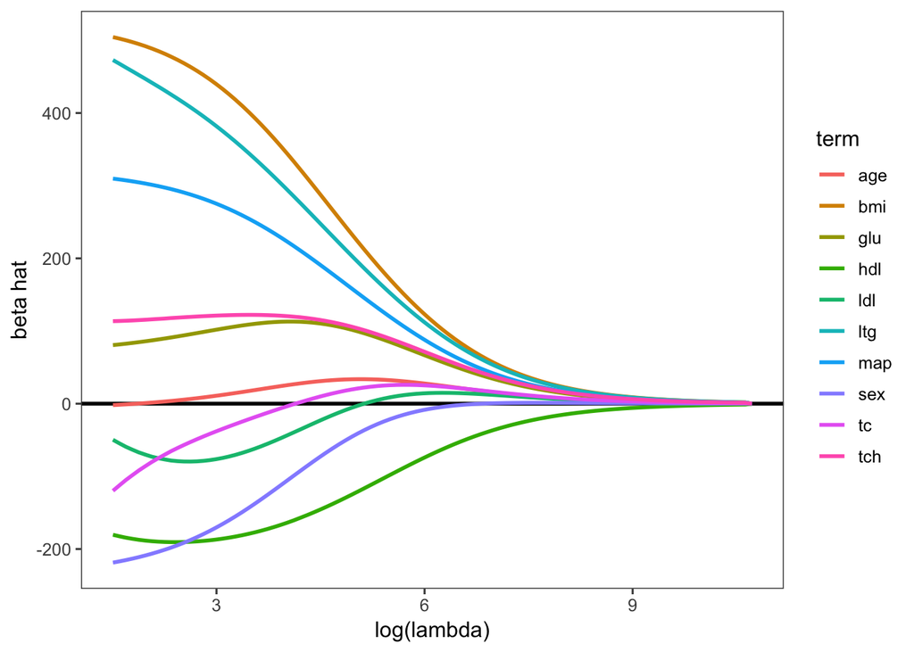

```r
set.seed(23)
ridge_fit_cv = cv.glmnet(x = X, y = y, alpha = 0)
tidied = tidy(ridge_fit) %>% filter(term != "(Intercept)")
p_ridge = ggplot(tidied, aes(log(lambda), estimate, group = term, color = term)) +
  geom_hline(yintercept = 0, size = 1) +
  geom_line(size = 1) +
  ylab("beta hat")
p_ridge
```

To explore the results, we can use two functions `tidy` and `glance` from the broom package.

```r
tidied_cv = tidy(ridge_fit_cv)
glance_cv = glance(ridge_fit_cv)
```

Then we can plot results using `ggplot`.

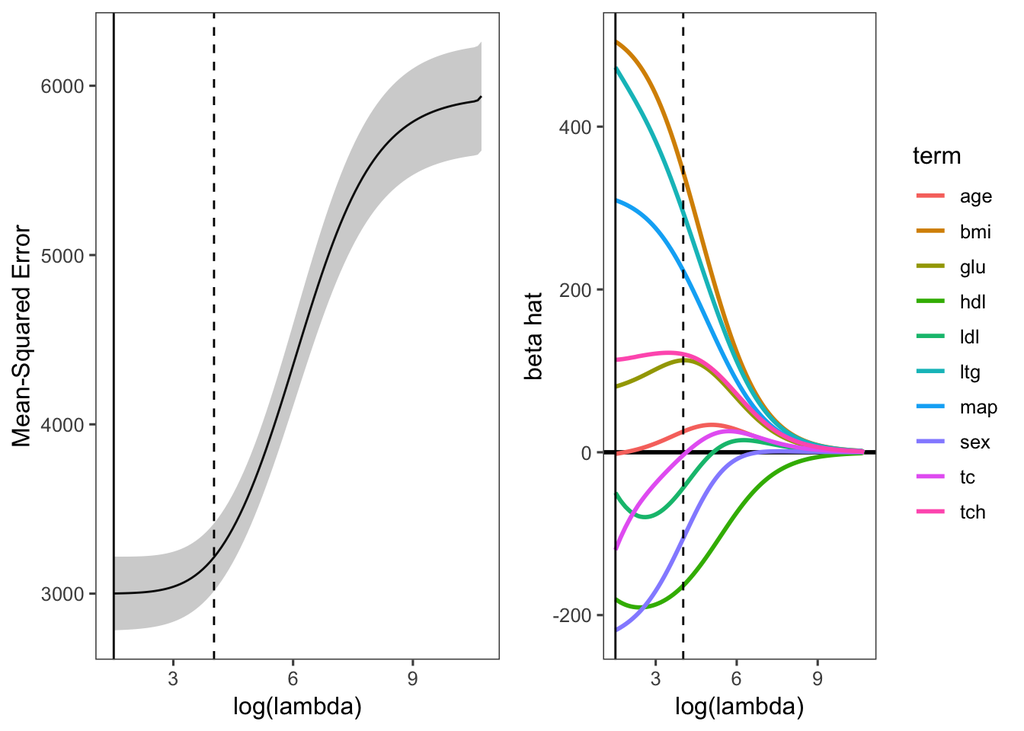

```r
p_ridge_cv = ggplot(tidied_cv, aes(log(lambda), estimate)) +
  geom_line() +
  geom_ribbon(aes(ymin = conf.low, ymax = conf.high), alpha = .25) +
  geom_vline(xintercept = log(glance_cv$lambda.min)) +
  geom_vline(xintercept = log(glance_cv$lambda.1se), lty = 2) +
  ylab("Mean-Squared Error")
p_ridge = p_ridge +
  geom_vline(xintercept = log(glance_cv$lambda.min)) +
  geom_vline(xintercept = log(glance_cv$lambda.1se), lty = 2)
plot_grid(p_ridge_cv, p_ridge)
```

The same procedure works for Lasso regression by changing `alpha = 0` to `alpha = 1`.

**Question 11**: Try to fit the Lasso model to the `diabetes` dataset.

```r
set.seed(23)
lasso_fit = glmnet(x = X, y = y, alpha = 1)
tidied = tidy(lasso_fit) %>% filter(term != "(Intercept)")
lasso_fit_cv = cv.glmnet(x = X, y = y, alpha = 1)
tidied_cv = tidy(lasso_fit_cv)
glance_cv = glance(lasso_fit_cv)
p_lasso = ggplot(tidied, aes(log(lambda), estimate, group = term, color = term)) +
  geom_hline(yintercept = 0, size = 1) +
  geom_line(size = 1) +
  ylab("beta hat") +
  geom_vline(xintercept = log(glance_cv$lambda.min)) +
  geom_vline(xintercept = log(glance_cv$lambda.1se), lty = 2)
```

**Question 12**: Compare ridge and Lasso fit by plotting them side-by-side using `plot_grid`.

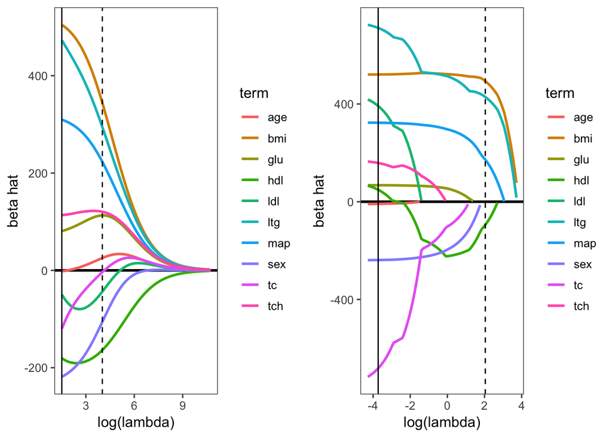

```r
plot_grid(p_ridge, p_lasso)
```

## Session Info for Reproducibility

At the end of a R markdown notebook, you should always include the session information. This contains the operating system, version numbers of R, and R packages that you used during the analysis. Your collaborator or yourself in a few month will be thankful for this information as it will allow her or him to rerun the analysis without much additional effort.

[session information not shown]